# Risk Factor Analysis

## Outcome Variable

**Outcome Variable:** ever_co

## Predictor Variables

**Intervention Variable:** perdiar6

**Adjustment Set:**

- arm
- sex
- W_mage
- meducyrs
- feducyrs
- hhwealth_quart
- hfoodsec
- W_mhtcm
- W_mwtkg
- W_mbmi
- W_birthwt
- W_birthlen
- W_nrooms
- month
- brthmon
- impfloor
- impsan
- safeh20
- delta_W_mage
- delta_meducyrs
- delta_feducyrs
- delta_hhwealth_quart
- delta_hfoodsec
- delta_W_mhtcm
- delta_W_mwtkg
- delta_W_mbmi
- delta_W_birthwt
- delta_W_birthlen
- delta_W_nrooms
- delta_month
- delta_brthmon
- delta_impfloor
- delta_impsan
- delta_safeh20

## Stratifying Variables

The analysis was stratified on these variable(s):

- agecat
- studyid
- country

## Data Summary

| agecat | studyid | country | perdiar6 | ever_co | n_cell | n |
| --- | --- | --- | --- | --- | --- | --- |
| 0-24 months | CMIN | BANGLADESH | 0% | 0 | 62 | 271 |
| 0-24 months | CMIN | BANGLADESH | 0% | 1 | 32 | 271 |
| 0-24 months | CMIN | BANGLADESH | (0%, 5%] | 0 | 44 | 271 |
| 0-24 months | CMIN | BANGLADESH | (0%, 5%] | 1 | 19 | 271 |
| 0-24 months | CMIN | BANGLADESH | >5% | 0 | 73 | 271 |
| 0-24 months | CMIN | BANGLADESH | >5% | 1 | 41 | 271 |
| 0-24 months | CONTENT | PERU | 0% | 0 | 115 | 215 |
| 0-24 months | CONTENT | PERU | 0% | 1 | 0 | 215 |
| 0-24 months | CONTENT | PERU | (0%, 5%] | 0 | 43 | 215 |
| 0-24 months | CONTENT | PERU | (0%, 5%] | 1 | 0 | 215 |
| 0-24 months | CONTENT | PERU | >5% | 0 | 57 | 215 |
| 0-24 months | CONTENT | PERU | >5% | 1 | 0 | 215 |
| 0-24 months | EE | PAKISTAN | 0% | 0 | 188 | 379 |
| 0-24 months | EE | PAKISTAN | 0% | 1 | 154 | 379 |
| 0-24 months | EE | PAKISTAN | (0%, 5%] | 0 | 20 | 379 |
| 0-24 months | EE | PAKISTAN | (0%, 5%] | 1 | 15 | 379 |
| 0-24 months | EE | PAKISTAN | >5% | 0 | 1 | 379 |
| 0-24 months | EE | PAKISTAN | >5% | 1 | 1 | 379 |
| 0-24 months | MAL-ED | BANGLADESH | 0% | 0 | 70 | 263 |
| 0-24 months | MAL-ED | BANGLADESH | 0% | 1 | 15 | 263 |
| 0-24 months | MAL-ED | BANGLADESH | (0%, 5%] | 0 | 83 | 263 |
| 0-24 months | MAL-ED | BANGLADESH | (0%, 5%] | 1 | 15 | 263 |
| 0-24 months | MAL-ED | BANGLADESH | >5% | 0 | 71 | 263 |
| 0-24 months | MAL-ED | BANGLADESH | >5% | 1 | 9 | 263 |
| 0-24 months | MAL-ED | BRAZIL | 0% | 0 | 213 | 233 |
| 0-24 months | MAL-ED | BRAZIL | 0% | 1 | 3 | 233 |
| 0-24 months | MAL-ED | BRAZIL | (0%, 5%] | 0 | 15 | 233 |
| 0-24 months | MAL-ED | BRAZIL | (0%, 5%] | 1 | 0 | 233 |
| 0-24 months | MAL-ED | BRAZIL | >5% | 0 | 2 | 233 |
| 0-24 months | MAL-ED | BRAZIL | >5% | 1 | 0 | 233 |

[output cut: 204 more lines]

The following strata were considered:

- agecat: 0-24 months, studyid: CMIN, country: BANGLADESH
- agecat: 0-24 months, studyid: CONTENT, country: PERU
- agecat: 0-24 months, studyid: EE, country: PAKISTAN
- agecat: 0-24 months, studyid: MAL-ED, country: BANGLADESH
- agecat: 0-24 months, studyid: MAL-ED, country: BRAZIL
- agecat: 0-24 months, studyid: MAL-ED, country: INDIA
- agecat: 0-24 months, studyid: MAL-ED, country: NEPAL
- agecat: 0-24 months, studyid: MAL-ED, country: PERU
- agecat: 0-24 months, studyid: MAL-ED, country: SOUTH AFRICA
- agecat: 0-24 months, studyid: MAL-ED, country: TANZANIA, UNITED REPUBLIC OF
- agecat: 0-24 months, studyid: NIH-Birth, country: BANGLADESH
- agecat: 0-24 months, studyid: NIH-Crypto, country: BANGLADESH
- agecat: 0-24 months, studyid: PROVIDE, country: BANGLADESH
- agecat: 0-6 months, studyid: CMIN, country: BANGLADESH
- agecat: 0-6 months, studyid: CONTENT, country: PERU
- agecat: 0-6 months, studyid: EE, country: PAKISTAN
- agecat: 0-6 months, studyid: MAL-ED, country: BANGLADESH
- agecat: 0-6 months, studyid: MAL-ED, country: BRAZIL
- agecat: 0-6 months, studyid: MAL-ED, country: INDIA
- agecat: 0-6 months, studyid: MAL-ED, country: NEPAL
- agecat: 0-6 months, studyid: MAL-ED, country: PERU
- agecat: 0-6 months, studyid: MAL-ED, country: SOUTH AFRICA
- agecat: 0-6 months, studyid: MAL-ED, country: TANZANIA, UNITED REPUBLIC OF
- agecat: 0-6 months, studyid: NIH-Birth, country: BANGLADESH
- agecat: 0-6 months, studyid: NIH-Crypto, country: BANGLADESH
- agecat: 0-6 months, studyid: PROVIDE, country: BANGLADESH
- agecat: 6-24 months, studyid: CMIN, country: BANGLADESH
- agecat: 6-24 months, studyid: CONTENT, country: PERU
- agecat: 6-24 months, studyid: EE, country: PAKISTAN
- agecat: 6-24 months, studyid: MAL-ED, country: BANGLADESH
- agecat: 6-24 months, studyid: MAL-ED, country: BRAZIL
- agecat: 6-24 months, studyid: MAL-ED, country: INDIA
- agecat: 6-24 months, studyid: MAL-ED, country: NEPAL
- agecat: 6-24 months, studyid: MAL-ED, country: PERU
- agecat: 6-24 months, studyid: MAL-ED, country: SOUTH AFRICA
- agecat: 6-24 months, studyid: MAL-ED, country: TANZANIA, UNITED REPUBLIC OF
- agecat: 6-24 months, studyid: NIH-Birth, country: BANGLADESH
- agecat: 6-24 months, studyid: NIH-Crypto, country: BANGLADESH
- agecat: 6-24 months, studyid: PROVIDE, country: BANGLADESH

### Dropped Strata

Some strata were dropped due to rare outcomes:

- agecat: 0-24 months, studyid: CONTENT, country: PERU
- agecat: 0-24 months, studyid: EE, country: PAKISTAN
- agecat: 0-24 months, studyid: MAL-ED, country: BRAZIL
- agecat: 0-24 months, studyid: MAL-ED, country: NEPAL
- agecat: 0-24 months, studyid: MAL-ED, country: PERU
- agecat: 0-24 months, studyid: MAL-ED, country: SOUTH AFRICA
- agecat: 0-24 months, studyid: MAL-ED, country: TANZANIA, UNITED REPUBLIC OF
- agecat: 0-6 months, studyid: CMIN, country: BANGLADESH
- agecat: 0-6 months, studyid: CONTENT, country: PERU
- agecat: 0-6 months, studyid: EE, country: PAKISTAN
- agecat: 0-6 months, studyid: MAL-ED, country: BANGLADESH
- agecat: 0-6 months, studyid: MAL-ED, country: BRAZIL
- agecat: 0-6 months, studyid: MAL-ED, country: NEPAL
- agecat: 0-6 months, studyid: MAL-ED, country: PERU
- agecat: 0-6 months, studyid: MAL-ED, country: SOUTH AFRICA
- agecat: 0-6 months, studyid: MAL-ED, country: TANZANIA, UNITED REPUBLIC OF
- agecat: 0-6 months, studyid: NIH-Crypto, country: BANGLADESH
- agecat: 6-24 months, studyid: CONTENT, country: PERU
- agecat: 6-24 months, studyid: EE, country: PAKISTAN
- agecat: 6-24 months, studyid: MAL-ED, country: BRAZIL
- agecat: 6-24 months, studyid: MAL-ED, country: NEPAL
- agecat: 6-24 months, studyid: MAL-ED, country: PERU
- agecat: 6-24 months, studyid: MAL-ED, country: SOUTH AFRICA
- agecat: 6-24 months, studyid: MAL-ED, country: TANZANIA, UNITED REPUBLIC OF

## Methods Detail

We’re interested in the causal parameters $E[Y_a]$ for all values of $a \in \mathcal{A}$. These parameters represent the mean outcome if, possibly contrary to fact, we intervened to set all units to have $A=a$. Under the randomization and positivity assumptions, these are identified by the statistical parameters $\psi_a=E_W[E_{Y|A,W}(Y|A=a,W)]$. In addition, we’re interested in the mean of $Y$, $E[Y]$ under no intervention (the observed mean). We will estimate these parameters by using SuperLearner to fit the relevant likelihood factors – $E_{Y|A,W}(Y|A=a,W)$ and $p(A=a|W)$, and then updating our likelihood fit using a joint TMLE.

For unadjusted analyses ($W=\{\}$), initial likelihoods were estimated using Lrnr_glm to estimate the simple $E(Y|A)$ and Lrnr_mean to estimate $p(A)$. For adjusted analyses, a small library containing Lrnr_glmnet, Lrnr_xgboost, and Lrnr_mean was used.

Having estimated these parameters, we will then use the delta method to estimate relative risks and attributable risks relative to a prespecified baseline level of $A$.

# Results Detail

## Results Plots

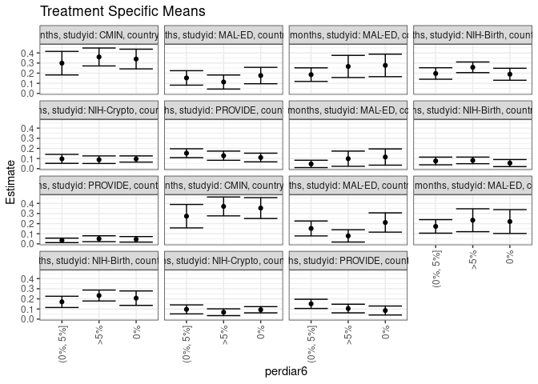

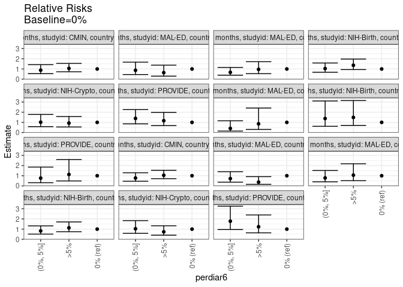

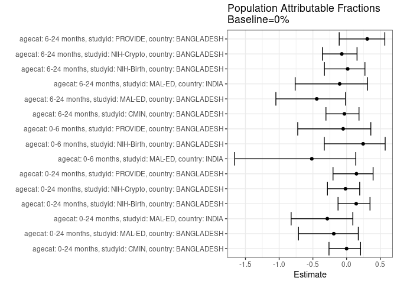

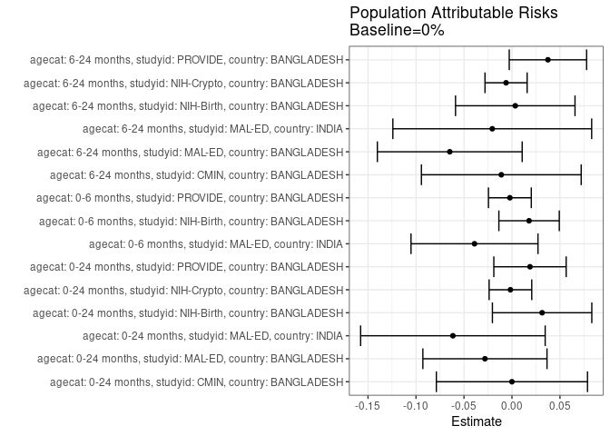

## Results Table

### Parameter: TSM

| agecat | studyid | country | intervention_level | baseline_level | estimate | ci_lower | ci_upper |
| --- | --- | --- | --- | --- | --- | --- | --- |
| 0-24 months | CMIN | BANGLADESH | 0% | NA | 0.3395345 | 0.2421222 | 0.4369467 |
| 0-24 months | CMIN | BANGLADESH | (0%, 5%] | NA | 0.2986993 | 0.1824824 | 0.4149162 |
| 0-24 months | CMIN | BANGLADESH | >5% | NA | 0.3598486 | 0.2711839 | 0.4485133 |
| 0-24 months | MAL-ED | BANGLADESH | 0% | NA | 0.1764706 | 0.0952733 | 0.2576679 |
| 0-24 months | MAL-ED | BANGLADESH | (0%, 5%] | NA | 0.1530612 | 0.0816411 | 0.2244814 |
| 0-24 months | MAL-ED | BANGLADESH | >5% | NA | 0.1125000 | 0.0431270 | 0.1818730 |
| 0-24 months | MAL-ED | INDIA | 0% | NA | 0.2767036 | 0.1654286 | 0.3879785 |
| 0-24 months | MAL-ED | INDIA | (0%, 5%] | NA | 0.1853846 | 0.1183212 | 0.2524479 |
| 0-24 months | MAL-ED | INDIA | >5% | NA | 0.2663968 | 0.1570463 | 0.3757473 |
| 0-24 months | NIH-Birth | BANGLADESH | 0% | NA | 0.1892154 | 0.1301425 | 0.2482884 |
| 0-24 months | NIH-Birth | BANGLADESH | (0%, 5%] | NA | 0.1966355 | 0.1398747 | 0.2533963 |
| 0-24 months | NIH-Birth | BANGLADESH | >5% | NA | 0.2578300 | 0.2051874 | 0.3104726 |
| 0-24 months | NIH-Crypto | BANGLADESH | 0% | NA | 0.0952679 | 0.0646375 | 0.1258983 |
| 0-24 months | NIH-Crypto | BANGLADESH | (0%, 5%] | NA | 0.0966437 | 0.0522100 | 0.1410774 |
| 0-24 months | NIH-Crypto | BANGLADESH | >5% | NA | 0.0883064 | 0.0508868 | 0.1257260 |
| 0-24 months | PROVIDE | BANGLADESH | 0% | NA | 0.1097936 | 0.0668878 | 0.1526995 |
| 0-24 months | PROVIDE | BANGLADESH | (0%, 5%] | NA | 0.1522649 | 0.1084533 | 0.1960765 |
| 0-24 months | PROVIDE | BANGLADESH | >5% | NA | 0.1278281 | 0.0823518 | 0.1733044 |
| 0-6 months | MAL-ED | INDIA | 0% | NA | 0.1147541 | 0.0346110 | 0.1948972 |
| 0-6 months | MAL-ED | INDIA | (0%, 5%] | NA | 0.0465116 | 0.0100985 | 0.0829248 |
| 0-6 months | MAL-ED | INDIA | >5% | NA | 0.0983607 | 0.0234787 | 0.1732426 |
| 0-6 months | NIH-Birth | BANGLADESH | 0% | NA | 0.0548780 | 0.0199945 | 0.0897616 |
| 0-6 months | NIH-Birth | BANGLADESH | (0%, 5%] | NA | 0.0756757 | 0.0375337 | 0.1138177 |
| 0-6 months | NIH-Birth | BANGLADESH | >5% | NA | 0.0814815 | 0.0488234 | 0.1141396 |
| 0-6 months | PROVIDE | BANGLADESH | 0% | NA | 0.0450450 | 0.0177429 | 0.0723472 |
| 0-6 months | PROVIDE | BANGLADESH | (0%, 5%] | NA | 0.0344828 | 0.0123304 | 0.0566351 |
| 0-6 months | PROVIDE | BANGLADESH | >5% | NA | 0.0506912 | 0.0214834 | 0.0798990 |
| 6-24 months | CMIN | BANGLADESH | 0% | NA | 0.3537566 | 0.2505836 | 0.4569297 |
| 6-24 months | CMIN | BANGLADESH | (0%, 5%] | NA | 0.2734372 | 0.1574159 | 0.3894585 |
| 6-24 months | CMIN | BANGLADESH | >5% | NA | 0.3697962 | 0.2766234 | 0.4629690 |
| 6-24 months | MAL-ED | BANGLADESH | 0% | NA | 0.2112676 | 0.1161172 | 0.3064180 |
| 6-24 months | MAL-ED | BANGLADESH | (0%, 5%] | NA | 0.1521739 | 0.0786230 | 0.2257248 |
| 6-24 months | MAL-ED | BANGLADESH | >5% | NA | 0.0789474 | 0.0181951 | 0.1396997 |
| 6-24 months | MAL-ED | INDIA | 0% | NA | 0.2205373 | 0.1029015 | 0.3381731 |
| 6-24 months | MAL-ED | INDIA | (0%, 5%] | NA | 0.1725996 | 0.1056837 | 0.2395155 |
| 6-24 months | MAL-ED | INDIA | >5% | NA | 0.2334759 | 0.1204096 | 0.3465422 |
| 6-24 months | NIH-Birth | BANGLADESH | 0% | NA | 0.2069071 | 0.1355435 | 0.2782708 |
| 6-24 months | NIH-Birth | BANGLADESH | (0%, 5%] | NA | 0.1701686 | 0.1145349 | 0.2258024 |
| 6-24 months | NIH-Birth | BANGLADESH | >5% | NA | 0.2330254 | 0.1790131 | 0.2870377 |
| 6-24 months | NIH-Crypto | BANGLADESH | 0% | NA | 0.0924626 | 0.0617736 | 0.1231515 |
| 6-24 months | NIH-Crypto | BANGLADESH | (0%, 5%] | NA | 0.0959836 | 0.0515739 | 0.1403933 |
| 6-24 months | NIH-Crypto | BANGLADESH | >5% | NA | 0.0678474 | 0.0343385 | 0.1013563 |
| 6-24 months | PROVIDE | BANGLADESH | 0% | NA | 0.0846975 | 0.0403310 | 0.1290640 |
| 6-24 months | PROVIDE | BANGLADESH | (0%, 5%] | NA | 0.1505394 | 0.1049609 | 0.1961180 |
| 6-24 months | PROVIDE | BANGLADESH | >5% | NA | 0.1043683 | 0.0617514 | 0.1469853 |

### Parameter: E(Y)

| agecat | studyid | country | intervention_level | baseline_level | estimate | ci_lower | ci_upper |
| --- | --- | --- | --- | --- | --- | --- | --- |
| 0-24 months | CMIN | BANGLADESH | NA | NA | 0.3394834 | 0.2830004 | 0.3959663 |
| 0-24 months | MAL-ED | BANGLADESH | NA | NA | 0.1482890 | 0.1052563 | 0.1913216 |
| 0-24 months | MAL-ED | INDIA | NA | NA | 0.2151394 | 0.1642023 | 0.2660766 |
| 0-24 months | NIH-Birth | BANGLADESH | NA | NA | 0.2206119 | 0.1879724 | 0.2532514 |
| 0-24 months | NIH-Crypto | BANGLADESH | NA | NA | 0.0936675 | 0.0729118 | 0.1144233 |
| 0-24 months | PROVIDE | BANGLADESH | NA | NA | 0.1285714 | 0.1037574 | 0.1533855 |
| 0-6 months | MAL-ED | INDIA | NA | NA | 0.0756972 | 0.0429084 | 0.1084860 |
| 0-6 months | NIH-Birth | BANGLADESH | NA | NA | 0.0726979 | 0.0522275 | 0.0931683 |
| 0-6 months | PROVIDE | BANGLADESH | NA | NA | 0.0428571 | 0.0278427 | 0.0578716 |
| 6-24 months | CMIN | BANGLADESH | NA | NA | 0.3426295 | 0.2837999 | 0.4014590 |
| 6-24 months | MAL-ED | BANGLADESH | NA | NA | 0.1464435 | 0.1015265 | 0.1913605 |
| 6-24 months | MAL-ED | INDIA | NA | NA | 0.2000000 | 0.1487493 | 0.2512507 |
| 6-24 months | NIH-Birth | BANGLADESH | NA | NA | 0.2103321 | 0.1759902 | 0.2446740 |
| 6-24 months | NIH-Crypto | BANGLADESH | NA | NA | 0.0863014 | 0.0659171 | 0.1066856 |
| 6-24 months | PROVIDE | BANGLADESH | NA | NA | 0.1221498 | 0.0962275 | 0.1480722 |

### Parameter: RR

| agecat | studyid | country | intervention_level | baseline_level | estimate | ci_lower | ci_upper |
| --- | --- | --- | --- | --- | --- | --- | --- |
| 0-24 months | CMIN | BANGLADESH | 0% | 0% | 1.0000000 | 1.0000000 | 1.0000000 |
| 0-24 months | CMIN | BANGLADESH | (0%, 5%] | 0% | 0.8797320 | 0.5424423 | 1.4267476 |
| 0-24 months | CMIN | BANGLADESH | >5% | 0% | 1.0598294 | 0.7258081 | 1.5475692 |
| 0-24 months | MAL-ED | BANGLADESH | 0% | 0% | 1.0000000 | 1.0000000 | 1.0000000 |
| 0-24 months | MAL-ED | BANGLADESH | (0%, 5%] | 0% | 0.8673469 | 0.4503955 | 1.6702892 |
| 0-24 months | MAL-ED | BANGLADESH | >5% | 0% | 0.6375000 | 0.2953502 | 1.3760149 |
| 0-24 months | MAL-ED | INDIA | 0% | 0% | 1.0000000 | 1.0000000 | 1.0000000 |
| 0-24 months | MAL-ED | INDIA | (0%, 5%] | 0% | 0.6699754 | 0.3897280 | 1.1517444 |
| 0-24 months | MAL-ED | INDIA | >5% | 0% | 0.9627515 | 0.5404491 | 1.7150375 |
| 0-24 months | NIH-Birth | BANGLADESH | 0% | 0% | 1.0000000 | 1.0000000 | 1.0000000 |
| 0-24 months | NIH-Birth | BANGLADESH | (0%, 5%] | 0% | 1.0392149 | 0.6800762 | 1.5880097 |
| 0-24 months | NIH-Birth | BANGLADESH | >5% | 0% | 1.3626264 | 0.9392489 | 1.9768463 |
| 0-24 months | NIH-Crypto | BANGLADESH | 0% | 0% | 1.0000000 | 1.0000000 | 1.0000000 |
| 0-24 months | NIH-Crypto | BANGLADESH | (0%, 5%] | 0% | 1.0144418 | 0.5789236 | 1.7775957 |
| 0-24 months | NIH-Crypto | BANGLADESH | >5% | 0% | 0.9269273 | 0.5450352 | 1.5764016 |
| 0-24 months | PROVIDE | BANGLADESH | 0% | 0% | 1.0000000 | 1.0000000 | 1.0000000 |
| 0-24 months | PROVIDE | BANGLADESH | (0%, 5%] | 0% | 1.3868286 | 0.8533596 | 2.2537902 |
| 0-24 months | PROVIDE | BANGLADESH | >5% | 0% | 1.1642579 | 0.6851523 | 1.9783871 |
| 0-6 months | MAL-ED | INDIA | 0% | 0% | 1.0000000 | 1.0000000 | 1.0000000 |
| 0-6 months | MAL-ED | INDIA | (0%, 5%] | 0% | 0.4053156 | 0.1419600 | 1.1572328 |
| 0-6 months | MAL-ED | INDIA | >5% | 0% | 0.8571429 | 0.3050544 | 2.4084031 |
| 0-6 months | NIH-Birth | BANGLADESH | 0% | 0% | 1.0000000 | 1.0000000 | 1.0000000 |
| 0-6 months | NIH-Birth | BANGLADESH | (0%, 5%] | 0% | 1.3789790 | 0.6126960 | 3.1036321 |
| 0-6 months | NIH-Birth | BANGLADESH | >5% | 0% | 1.4847737 | 0.7003297 | 3.1478783 |
| 0-6 months | PROVIDE | BANGLADESH | 0% | 0% | 1.0000000 | 1.0000000 | 1.0000000 |
| 0-6 months | PROVIDE | BANGLADESH | (0%, 5%] | 0% | 0.7655172 | 0.3165046 | 1.8515265 |
| 0-6 months | PROVIDE | BANGLADESH | >5% | 0% | 1.1253456 | 0.4876348 | 2.5970311 |
| 6-24 months | CMIN | BANGLADESH | 0% | 0% | 1.0000000 | 1.0000000 | 1.0000000 |
| 6-24 months | CMIN | BANGLADESH | (0%, 5%] | 0% | 0.7729528 | 0.4621183 | 1.2928638 |
| 6-24 months | CMIN | BANGLADESH | >5% | 0% | 1.0453406 | 0.7110953 | 1.5366956 |
| 6-24 months | MAL-ED | BANGLADESH | 0% | 0% | 1.0000000 | 1.0000000 | 1.0000000 |
| 6-24 months | MAL-ED | BANGLADESH | (0%, 5%] | 0% | 0.7202899 | 0.3720423 | 1.3945120 |
| 6-24 months | MAL-ED | BANGLADESH | >5% | 0% | 0.3736842 | 0.1532046 | 0.9114602 |
| 6-24 months | MAL-ED | INDIA | 0% | 0% | 1.0000000 | 1.0000000 | 1.0000000 |
| 6-24 months | MAL-ED | INDIA | (0%, 5%] | 0% | 0.7826321 | 0.4042040 | 1.5153561 |
| 6-24 months | MAL-ED | INDIA | >5% | 0% | 1.0586684 | 0.5146216 | 2.1778697 |
| 6-24 months | NIH-Birth | BANGLADESH | 0% | 0% | 1.0000000 | 1.0000000 | 1.0000000 |
| 6-24 months | NIH-Birth | BANGLADESH | (0%, 5%] | 0% | 0.8224397 | 0.5124740 | 1.3198856 |
| 6-24 months | NIH-Birth | BANGLADESH | >5% | 0% | 1.1262319 | 0.7432522 | 1.7065516 |
| 6-24 months | NIH-Crypto | BANGLADESH | 0% | 0% | 1.0000000 | 1.0000000 | 1.0000000 |
| 6-24 months | NIH-Crypto | BANGLADESH | (0%, 5%] | 0% | 1.0380805 | 0.5878651 | 1.8330925 |
| 6-24 months | NIH-Crypto | BANGLADESH | >5% | 0% | 0.7337818 | 0.4050972 | 1.3291518 |
| 6-24 months | PROVIDE | BANGLADESH | 0% | 0% | 1.0000000 | 1.0000000 | 1.0000000 |
| 6-24 months | PROVIDE | BANGLADESH | (0%, 5%] | 0% | 1.7773769 | 0.9701249 | 3.2563527 |
| 6-24 months | PROVIDE | BANGLADESH | >5% | 0% | 1.2322475 | 0.6345936 | 2.3927661 |

### Parameter: PAR

| agecat | studyid | country | intervention_level | baseline_level | estimate | ci_lower | ci_upper |
| --- | --- | --- | --- | --- | --- | --- | --- |
| 0-24 months | CMIN | BANGLADESH | 0% | NA | -0.0000511 | -0.0787975 | 0.0786954 |
| 0-24 months | MAL-ED | BANGLADESH | 0% | NA | -0.0281816 | -0.0928591 | 0.0364958 |
| 0-24 months | MAL-ED | INDIA | 0% | NA | -0.0615641 | -0.1577217 | 0.0345935 |
| 0-24 months | NIH-Birth | BANGLADESH | 0% | NA | 0.0313965 | -0.0203893 | 0.0831822 |
| 0-24 months | NIH-Crypto | BANGLADESH | 0% | NA | -0.0016003 | -0.0238107 | 0.0206100 |
| 0-24 months | PROVIDE | BANGLADESH | 0% | NA | 0.0187778 | -0.0189100 | 0.0564657 |
| 0-6 months | MAL-ED | INDIA | 0% | NA | -0.0390569 | -0.1052092 | 0.0270954 |
| 0-6 months | NIH-Birth | BANGLADESH | 0% | NA | 0.0178199 | -0.0136619 | 0.0493016 |
| 0-6 months | PROVIDE | BANGLADESH | 0% | NA | -0.0021879 | -0.0245047 | 0.0201289 |
| 6-24 months | CMIN | BANGLADESH | 0% | NA | -0.0111272 | -0.0943721 | 0.0721178 |
| 6-24 months | MAL-ED | BANGLADESH | 0% | NA | -0.0648241 | -0.1402695 | 0.0106213 |
| 6-24 months | MAL-ED | INDIA | 0% | NA | -0.0205373 | -0.1241131 | 0.0830385 |
| 6-24 months | NIH-Birth | BANGLADESH | 0% | NA | 0.0034250 | -0.0588280 | 0.0656779 |
| 6-24 months | NIH-Crypto | BANGLADESH | 0% | NA | -0.0061612 | -0.0281115 | 0.0157891 |
| 6-24 months | PROVIDE | BANGLADESH | 0% | NA | 0.0374523 | -0.0028487 | 0.0777533 |

### Parameter: PAF

| agecat | studyid | country | intervention_level | baseline_level | estimate | ci_lower | ci_upper |
| --- | --- | --- | --- | --- | --- | --- | --- |
| 0-24 months | CMIN | BANGLADESH | 0% | NA | -0.0001504 | -0.2612141 | 0.2068746 |
| 0-24 months | MAL-ED | BANGLADESH | 0% | NA | -0.1900452 | -0.7139097 | 0.1736976 |
| 0-24 months | MAL-ED | INDIA | 0% | NA | -0.2861592 | -0.8225780 | 0.0923816 |
| 0-24 months | NIH-Birth | BANGLADESH | 0% | NA | 0.1423154 | -0.1268182 | 0.3471680 |
| 0-24 months | NIH-Crypto | BANGLADESH | 0% | NA | -0.0170854 | -0.2840893 | 0.1943997 |
| 0-24 months | PROVIDE | BANGLADESH | 0% | NA | 0.1460497 | -0.2014340 | 0.3930327 |
| 0-6 months | MAL-ED | INDIA | 0% | NA | -0.5159620 | -1.6595874 | 0.1359032 |
| 0-6 months | NIH-Birth | BANGLADESH | 0% | NA | 0.2451220 | -0.3311018 | 0.5719029 |
| 0-6 months | PROVIDE | BANGLADESH | 0% | NA | -0.0510511 | -0.7245378 | 0.3594178 |
| 6-24 months | CMIN | BANGLADESH | 0% | NA | -0.0324758 | -0.3062998 | 0.1839498 |
| 6-24 months | MAL-ED | BANGLADESH | 0% | NA | -0.4426559 | -1.0488447 | -0.0158194 |
| 6-24 months | MAL-ED | INDIA | 0% | NA | -0.1026867 | -0.7628302 | 0.3102468 |
| 6-24 months | NIH-Birth | BANGLADESH | 0% | NA | 0.0162836 | -0.3290871 | 0.2719077 |
| 6-24 months | NIH-Crypto | BANGLADESH | 0% | NA | -0.0713919 | -0.3581111 | 0.1547963 |
| 6-24 months | PROVIDE | BANGLADESH | 0% | NA | 0.3066096 | -0.1097803 | 0.5667699 |